Statistiques en grande dimension supérieure Yassine et Exaucé CMI ISI 11 Décembre 2021

# Données

Chargons les données.

```r
load("Devoir301221.RData")
data<-as_tibble(devoir201221)
paged_table(data)
```

| TDM | T | HR | PR | CL | PD | MA | SI | FM | SH |
| --- | --- | --- | --- | --- | --- | --- | --- | --- | --- |
| 214.4 | 9.05 | 61.46 | 142.08 | 0.000 | 55.41 | 40 | 36 | -16.6 | 19.3 |
| 16.1 | 24.76 | 69.99 | 155.98 | 0.049 | 98.77 | 36 | 36 | -15.0 | 27.9 |
| 214.9 | 13.19 | 77.81 | 151.43 | 0.074 | 128.55 | 40 | 43 | -1.2 | 40.8 |
| 267.8 | 3.97 | 75.17 | 150.02 | 0.044 | 53.83 | 41 | 39 | -10.0 | 16.8 |
| 166.6 | 17.10 | 73.56 | 161.80 | 0.119 | 84.64 | 40 | 44 | -16.3 | 35.9 |
| 185.6 | 14.38 | 65.67 | 143.87 | 0.000 | 81.47 | 43 | 42 | -17.6 | 29.8 |
| 250.1 | 16.53 | 85.91 | 138.33 | 0.037 | 172.92 | 41 | 32 | -9.5 | 15.8 |
| 224.4 | 9.39 | 64.54 | 157.67 | 0.021 | 95.31 | 43 | 36 | -16.6 | 19.4 |
| 340.6 | 7.44 | 75.61 | 157.90 | 0.106 | 162.00 | 38 | 34 | 0.1 | 34.9 |
| 186.1 | 11.38 | 72.44 | 165.99 | 0.142 | 59.28 | 41 | 34 | -25.5 | 32.2 |

[output cut: 45 more lines]

```r
dim(data)
```

```
## [1] 55 10
```

Nous avons 55 observations de 10 variables.

Fonction de standatisation:

```r
 normalit<-function(m){
   (m - min(m))/(max(m)-min(m))
 }
```

```r
colnames(data)
```

```
##  [1] "TDM" "T"   "HR"  "PR"  "CL"  "PD"  "MA"  "SI"  "FM"  "SH"
```

```r
data<-data %>%
    mutate_each(list(normalit),TDM ,T ,  HR , PR , CL  ,PD  ,MA , SI , FM , SH )
```

```r
paged_table(data)
```

| TDM | T | HR | PR | CL | PD | MA | SI | FM | SH |
| --- | --- | --- | --- | --- | --- | --- | --- | --- | --- |
| 0.25776680 | 0.35877551 | 0.30397614 | 0.20038722 | 0.00000000 | 0.17180832 | 0.33333333 | 0.35294118 | 0.47521866 | 0.119584055 |
| 0.00000000 | 1.00000000 | 0.47355865 | 0.53678606 | 0.17314488 | 0.47513116 | 0.00000000 | 0.35294118 | 0.52186589 | 0.268630849 |
| 0.25841674 | 0.52775510 | 0.62902584 | 0.42666989 | 0.26148410 | 0.68345575 | 0.33333333 | 0.76470588 | 0.92419825 | 0.492201040 |
| 0.32718055 | 0.15142857 | 0.57654076 | 0.39254598 | 0.15547703 | 0.16075551 | 0.41666667 | 0.52941176 | 0.66763848 | 0.076256499 |
| 0.19563239 | 0.68734694 | 0.54453280 | 0.67763795 | 0.42049470 | 0.37628541 | 0.33333333 | 0.82352941 | 0.48396501 | 0.407279029 |
| 0.22033017 | 0.57632653 | 0.38767396 | 0.24370765 | 0.00000000 | 0.35410983 | 0.58333333 | 0.70588235 | 0.44606414 | 0.301559792 |
| 0.30417262 | 0.66408163 | 0.79005964 | 0.10963214 | 0.13074205 | 0.99384400 | 0.41666667 | 0.11764706 | 0.68221574 | 0.058925477 |
| 0.27076563 | 0.37265306 | 0.36520875 | 0.57768635 | 0.07420495 | 0.45092690 | 0.58333333 | 0.35294118 | 0.47521866 | 0.121317158 |
| 0.42181204 | 0.29306122 | 0.58528827 | 0.58325266 | 0.37455830 | 0.91745366 | 0.16666667 | 0.23529412 | 0.96209913 | 0.389948007 |
| 0.22098011 | 0.45387755 | 0.52226640 | 0.77904163 | 0.50176678 | 0.19888073 | 0.41666667 | 0.23529412 | 0.21574344 | 0.343154246 |

[output cut: 45 more lines]

```r
lm<-lm(formula = TDM~., data = data)
summary(lm)
```

```
##
## Call:
## lm(formula = TDM ~ ., data = data)
##
## Residuals:
##      Min       1Q   Median       3Q      Max
## -0.11797 -0.04922 -0.00079  0.03500  0.48334
##
## Coefficients:
##              Estimate Std. Error t value Pr(>|t|)
## (Intercept)  0.164476   0.084175   1.954  0.05694 .
## T           -0.328719   0.058659  -5.604 1.20e-06 ***
## HR           0.019571   0.105576   0.185  0.85377
## PR           0.009948   0.092327   0.108  0.91467
## CL          -0.093292   0.119631  -0.780  0.43957
## PD           0.154913   0.052826   2.933  0.00527 **
## MA           0.257108   0.047841   5.374 2.62e-06 ***
## SI           0.030263   0.050639   0.598  0.55309
## FM           0.066911   0.052964   1.263  0.21298
## SH           0.096250   0.048110   2.001  0.05149 .
## ---
## Signif. codes:  0 '***' 0.001 '**' 0.01 '*' 0.05 '.' 0.1 ' ' 1
##
## Residual standard error: 0.08925 on 45 degrees of freedom
## Multiple R-squared:  0.6438, Adjusted R-squared:  0.5726
## F-statistic: 9.037 on 9 and 45 DF,  p-value: 1.232e-07
```

Données

```r
data_p<-data %>% mutate(T2=T**2,T3=T**3,HR2=HR**2,HR3=HR**3, PR2=PR**2,PR3=PR**3,CL2=CL**2,CL3=CL**3, PD2=PD**2, PD3=PD**3, MA2=MA**2,MA3=MA**3,SI2=SI**2,SI3=SI**3,FM2=FM**2,FM3=FM**3, SH2=SH**2,SH3=SH**3)
colnames(data_p)
```

```
##  [1] "TDM" "T"   "HR"  "PR"  "CL"  "PD"  "MA"  "SI"  "FM"  "SH"  "T2"  "T3"
## [13] "HR2" "HR3" "PR2" "PR3" "CL2" "CL3" "PD2" "PD3" "MA2" "MA3" "SI2" "SI3"
## [25] "FM2" "FM3" "SH2" "SH3"
```

Soit $\mathcal{X}$ l’ensemble des prédicateurs et $n$ le nombre de prédicateurs, nous avons donc cette nouvelle formulation du modèle:

$$TDM = \sum_{i=1}^{3}\sum_{j= 1 }^{n}\beta_{ij}X_i^j.$$

# Formulation du modèle

On sépare les données en apprentissage test.

Pour chaque méthode nous allons choisir le meilleur modèle en se servant de l’ensemble d’apprentissage puis nous allons les comparer en les testant sur l’ensemble de test.

Puis pour chaque meilleur modèle chosi nous allons tester son pouvoir de prédiction en calculant l’erreur de prédiction. Ainsi pour chaque critère nous allons comparer le pouvoir de prédiction de nos modèles.

Afin de desceler les variables pertinentes, pour chaque variable nous allons compter le nombre de cas où elle est considerée commme pertinente.C’est-à-dire pour une variable $X$ le nnomre de fois ou $X$, $X^2$ ou $X^3$ est apparue dans un modèle consideré comme meilleur.

## Fonctions utiles pour la suite

#### Récuperer la formule d’un modèle

```r
get_model_formula <- function(id, object, outcome){
  models <- summary(object)$which[id,-1]
  predictors <- names(which(models == TRUE))
  predictors <- paste(predictors, collapse = "+")
  as.formula(paste0(outcome, "~", predictors))
}
```

```r
set.seed(123)
```

#### Concaténer deux chaines de caractères.

```r
"%+%"<- function(x,y) paste(x,y,sep="")
```

Recupérer la liste de variables dans une formule ( ou dans un colnames d’un dataframe) de régression et garder que $X$ si $X$,$x^2$ ou $X^3$ est présent dans la liste.

```r
liste_vars <- function (suite) {
  if(class(suite)=="formula"){
    list_var<-as.character(suite[3])
    l<-as.vector(strsplit(list_var, '+ ')[[1]])
    l<-l[! l=="+" ]
  }else{
    l<-suite
  }
  l<-l[ l!="1"]


  for (i in 1:length(l)){
    l[i]<-str_replace(l[i],"2", "")
    l[i]<-str_replace(l[i],"3", "")

  }
  return (unique(l))
}
```

#### P-value

Une fonction qui permet de récuperer la pvalue d’un modèle

```r
lmp <- function (modelobject) {
    if (class(modelobject) != "lm") stop("Not an object of class 'lm' ")
    f <- summary(modelobject)$fstatistic
    p <- pf(f[1],f[2],f[3],lower.tail=F)
    attributes(p) <- NULL
    return(p)
}
```

#### Pertinence des variables

Data frame pour stocker l’importance des variable data: dataframe var : vvariable à expliquer

Nous allons pour chaque variable et pour chaque critère compter le nombre de fois où la variable est considerée comme importante.

```r
pertinence_vars_dataframe<-function(data, var,code){
  vars_names<-c(liste_vars(colnames(data %>% select(-c(var)))))
  vars_ncols<-length(vars_names)
  if(code==1){
  criteres<-c("aic","r2","pvalue")
  }else{
  criteres<-c("lasso")
  }
  criteres_ncols<-length(criteres)
    pertinence_vars = data.frame(matrix(vector(), criteres_ncols, vars_ncols,
                      dimnames=list(criteres, vars_names)), stringsAsFactors=F)

  pertinence_vars[is.na(pertinence_vars)] <- 0

  return(pertinence_vars)

}
```

## Critères

Pour les méthodes de sélection pas à pas ascendante, descendante où la méthode exhaustives. Nous allons utiliser 3 critères pour le choix du meilleur modèle:

- **P valeur**: c’est le risque de conclure à tort que les résultats obtenus ne peuvent pas être dus au hasard.
- **Aic**: Le critère AIC représente donc un compromis entre le biais, diminuant avec le nombre de paramètres libres, et la parcimonie, volonté de décrire les données avec le plus petit nombre de paramètres possibles.
- **R2 ajusté**: Le $R2$ une mesure qui permet d’évaluer le degré d’adéquation du modèle, sauf qu’elle augmente avec l’introduction d’une nouvelle variable, $R2 \ ajuste$ pénalise en revanche le nombre de variables.

En fin, pour comparer nos différentes méthodes de sélections, nous allons tester le pouvoir prédictif des modèles choisis en calculant le *RMSE* qui indique à quel point les données sont concentrées autour de la ligne de meilleur ajustement.

## Méthodes de sélection

### Méthode exhaustive

La régression par la méthode exhaustives est une approche de sélection de modèles qui consiste à tester toutes les combinaisons possibles des variables prédicteurs, puis à sélectionner le meilleur modèle en fonction de certains critères statistiques.

Cette méthode est très coûteuse en temps de calcul et devient même impossible pour **p** très grand. Il est dit dans **Hastie** qu’il toujours possible de le faire du moment où $p \leq 40$, ce qui est notre cas ($p=27$).

```r
subset<-function(data,var,reps){

  n<-nrow(data)
  p<-ncol(data)-1

  err_subset_pvalue <- rep(NA,reps)
  err_subset_r2  <- rep(NA,reps)
  err_subset_aic <- rep(NA,reps)

  # un dataframe pour sauvegarder la pertinence des variables.

  pertinence_subset<-pertinence_vars_dataframe(data,var,1)

  for(i in 1:reps){

    tr <- sample(1:n,floor(n*(2/3)))

    #Decoupage apprentissage/test
    data_train<-data_p %>% slice(tr)
    data_test<-data_p %>% slice(-tr)

    #meilleurs modèle de 1, 2,...p par la fonction regsubsets

    models <- regsubsets(as.formula(var%+%"~"%+%"."),data=data_train,nvmax=p,method=c("exhaustive"))
    error_aic <- matrix(NA,ncol=1,nrow=p)
    error_r2  <- matrix(NA,ncol=1,nrow=p)
    error_pvalue<-matrix(NA, ncol=1,nrow=p)

    #selection de meilleur modèleselon les 3 critères decris ci-haut
    for( j in 1:p){
      model_j<-get_model_formula(j,models,var)
      fit<-lm(model_j,data = data_train)


      error_aic[j]<-AIC(fit)
      error_r2[j] <-summary(fit)$adj.r.squared
      error_pvalue[j]<-lmp(fit)
    }


    # On entraine sur les données app
    best_model_aic <-get_model_formula(which.min(error_aic),models,var)
    model_aic <- lm(best_model_aic,data=data_train)

    best_model_r2 <-get_model_formula(which.min(error_r2),models,var)
    model_r2 <- lm(best_model_r2,data=data_train)

    best_model_pvalue <-get_model_formula(which.min(error_pvalue),models,var)
    model_pvalue <- lm(best_model_pvalue,data=data_train)

    Xtest<-data_test %>% select(-c(var))
    Ytest<-as.matrix(data_test %>% select(var))


    pred_test_aic <- predict(model_aic,Xtest)

    pred_test_r2 <- predict(model_r2,Xtest)

    pred_test_pvalue <- predict(model_pvalue,Xtest)


    err_subset_aic[i] <- RMSE(pred_test_aic,Ytest)
    err_subset_r2[i] <- RMSE(pred_test_r2,Ytest)
    err_subset_pvalue[i] <- RMSE(pred_test_pvalue,Ytest)

    ## On met à jour la base de donnée sur l'importance des variables

    liste_var_aic<-liste_vars(best_model_aic)
    for(var_pertinente in liste_var_aic){
      pertinence_subset["aic",var_pertinente]<-pertinence_subset["aic",var_pertinente]+1
    }
    liste_var_r2<-liste_vars(best_model_r2)
    for(var_pertinente in liste_var_r2){
      pertinence_subset["r2",var_pertinente]<-pertinence_subset["r2",var_pertinente]+1
    }

    liste_var_pvalue<-liste_vars(best_model_pvalue)
    for(var_pertinente in liste_var_pvalue){
      pertinence_subset["pvalue",var_pertinente]<-pertinence_subset["pvalue",var_pertinente]+1
    }
  }

  data_err=cbind(err_subset_r2,err_subset_aic,err_subset_pvalue)
  return(list("error"=data_err,"pertinence"=pertinence_subset))
}
```

```r
data<-data_p
reps<-10
var<-"TDM"

subset.TDM<-subset(data,var,reps)
pertinence.subset <-subset.TDM$pertinence
paged_table(pertinence.subset)
```

|  | T | HR | PR | CL | PD | MA | SI | FM | SH |
| --- | --- | --- | --- | --- | --- | --- | --- | --- | --- |
| aic | 10 | 8 | 8 | 9 | 9 | 10 | 10 | 7 | 8 |
| r2 | 2 | 0 | 0 | 0 | 0 | 8 | 0 | 0 | 0 |
| pvalue | 10 | 2 | 6 | 3 | 10 | 10 | 4 | 3 | 4 |

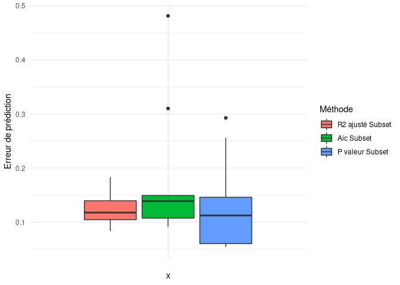

```r
error.subset <-as.data.frame(subset.TDM$error)
colnames(error.subset) <- c("R2 ajusté Subset","Aic Subset","P valeur Subset")

error.subset<- error.subset %>% mutate("ID"=seq.int(nrow(error.subset)))
error.subset <- error.subset %>% melt(id.var="ID")
colnames(error.subset) <- c("ID","Méthode","Erreur")

ggplot(error.subset) +
  aes(x = "", y = Erreur, fill = Méthode) +
  geom_boxplot(shape = "circle") +
  labs(y = "Erreur de prédiction") +
  theme_minimal()
```

```r
best.subset <- error.subset %>% filter(Méthode=="R2 ajusté Subset")
```

### Selection pas à pas ascendante et descendante

Comme nous l’avons susmentionner, la méthode précédente est impossible si $p >> 40$, nous avons deux autres méthodes similaire mais plus efficace.

- La sélection pas à pas ascendante , qui commence sans prédicteur dans le modèle, ajoute itérativement les prédicteurs les plus contributifs, et s’arrête lorsque l’amélioration n’est plus statistiquement significative.

```r
#data: les données
#var: variable à expliquer
#method: "forward" ou "backward"
#reps: nombre de répétitions

data<-data_p
reps<-30
var<-"TDM"
method<-"forward"

err_aic <- rep(0,reps)
err_r2  <- rep(0,reps)
err_pvalue <- rep(0,reps)

pertinence_stepwise<-pertinence_vars_dataframe(data,var,1)

n<-nrow(data)
for(k in 1:reps){

  #Decoupage apprentissage/test
  tr <- sample(1:n,floor(n*(2/3)))
  data_train<-data %>% slice(tr)
  data_test<-data %>% slice(-tr)

  Xtrain <- data_train %>% select(-c(var))
  Ytrain <- data_train %>% select(var)
  Xtest  <- data_test%>% select(-c(var))
  Ytest  <- data_test %>% select(var)

  model.full <- lm(as.formula(var%+%"~."), data[tr,])
  model.null <- lm(as.formula(var%+%"~1"), data[tr,])
  scope <- list(lower = model.null, upper = model.full)

  step.aic<-stepAIC(model.null, direction = method, scope = scope,trace=FALSE )
  pred_test_aic<- predict(step.aic,Xtest)
  err_aic[k] <- RMSE(as.numeric(unlist(Ytest)),pred_test_aic)


  step.r2 <- SignifReg(fit=model.null, alpha = 0.05, direction = method, scope = scope,criterion = "r-adj", trace=FALSE)
  pred_test_r2 <- predict(step.r2,Xtest)
  err_r2[k] <- RMSE(as.numeric(unlist(Ytest)),pred_test_r2)

  step.pvalue <- SignifReg(fit=model.null, alpha = 0.05, direction = method, criterion="p-value",scope = scope,trace=FALSE)
  pred_test_pvalue <- predict(step.pvalue,Xtest)
  err_pvalue[k] <- RMSE(as.numeric(unlist(Ytest)),pred_test_pvalue)

      ## On met à jour la base de donnée sur l'importance des variables

  liste_var_aic<-liste_vars(formula(step.aic))
    for(var_pertinente in liste_var_aic){
      if(is.na(var_pertinente)!=TRUE){
      pertinence_stepwise["aic",var_pertinente]<-pertinence_stepwise["aic",var_pertinente]+1
      }
    }
  liste_var_r2<-liste_vars(formula(step.r2))

    for(var_pertinente in liste_var_r2){
      if(is.na(var_pertinente)!=TRUE){
        pertinence_stepwise["r2",var_pertinente]<-pertinence_stepwise["r2",var_pertinente]+1
      }
    }

  liste_var_pvalue<-liste_vars(formula(step.pvalue))
    for(var_pertinente in liste_var_pvalue){
      if(is.na(var_pertinente) !=TRUE)
      pertinence_stepwise["pvalue",var_pertinente]<-pertinence_stepwise["pvalue",var_pertinente]+1
    }
}
data_err<-cbind(err_r2,err_aic, err_pvalue)

stepwise.forward.TDM<-list("error"=data_err, "pertinence"=pertinence_stepwise)
pertinence.stepwise.forward <-stepwise.forward.TDM$pertinence

paged_table(pertinence.stepwise.forward)
```

|  | T | HR | PR | CL | PD | MA | SI | FM | SH |
| --- | --- | --- | --- | --- | --- | --- | --- | --- | --- |
| aic | 30 | 8 | 11 | 17 | 30 | 30 | 24 | 23 | 16 |
| r2 | 30 | 1 | 5 | 8 | 30 | 30 | 18 | 13 | 8 |
| pvalue | 30 | 1 | 5 | 8 | 30 | 30 | 19 | 14 | 8 |

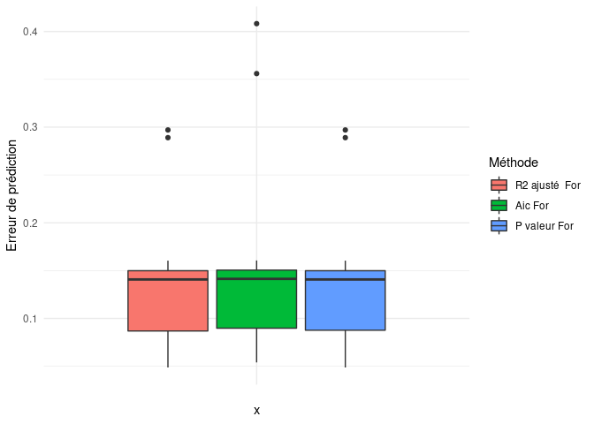

```r
error.stepwise.forward<-as.data.frame(stepwise.forward.TDM$error)
colnames(error.stepwise.forward) <- c("R2 ajusté  For","Aic For","P valeur For")

error.stepwise.forward<- error.stepwise.forward %>% mutate("ID"=seq.int(nrow(error.stepwise.forward)))
error.stepwise.forward <- error.stepwise.forward %>% melt(id.var="ID")
colnames(error.stepwise.forward) <- c("ID","Méthode","Erreur")

ggplot(error.stepwise.forward) +
  aes(x = "", y = Erreur, fill = Méthode) +
  geom_boxplot(shape = "circle") +
  labs(y = "Erreur de prédiction") +
  theme_minimal()
```

```r
best.stepwise.forward <- error.stepwise.forward %>% filter(Méthode=="Aic For")
```

- La sélection pas à pas descendante, qui commence avec tous les prédicteurs, élimine itérativement les prédicteurs les moins contributifs, et s’arrête lorsque tous les prédicteurs sont statistiquement significatifs.

```r
#data: les données
#var: variable à expliquer
#method: "forward" ou "backward"
#reps: nombre de répétitions

data<-data_p
reps<-30
var<-"TDM"
method<-"backward"




err_aic <- rep(0,reps)
err_r2  <- rep(0,reps)
err_pvalue <- rep(0,reps)


pertinence_stepwise<-pertinence_vars_dataframe(data,var,1)

n<-nrow(data)
for(k in 1:reps){

  #Decoupage apprentissage/test
  tr <- sample(1:n,floor(n*(2/3)))
  data_train<-data %>% slice(tr)
  data_test<-data %>% slice(-tr)

  Xtrain <- data_train %>% select(-c(var))
  Ytrain <- data_train %>% select(var)
  Xtest  <- data_test%>% select(-c(var))
  Ytest  <- data_test %>% select(var)



## extract the formula in the environment of cv.step
  model.full <- lm(as.formula(var%+%"~."), data[tr,])
  model.null <- lm(as.formula(var%+%"~1"), data[tr,])


  step.aic<-stepAIC(model.full, direction = method,trace=FALSE)
  pred_test_aic<- predict(step.aic,Xtest)
  err_aic[k] <- RMSE(as.numeric(unlist(Ytest)),pred_test_aic)


  step.r2 <- SignifReg(fit=model.full, scope = scope,alpha = 0.05, direction = method, criterion = "r-adj", trace=FALSE)
  pred_test_r2 <- predict(step.r2,Xtest)
  err_r2[k] <- RMSE(as.numeric(unlist(Ytest)),pred_test_r2)

  step.pvalue <- SignifReg(fit=model.full, alpha = 0.05, direction = method, criterion="p-value",trace=FALSE)
  pred_test_pvalue <- predict(step.pvalue,Xtest)
  err_pvalue[k] <- RMSE(as.numeric(unlist(Ytest)),pred_test_pvalue)

      ## On met à jour la base de donnée sur l'importance des variables

  liste_var_aic<-liste_vars(formula(step.aic))
    for(var_pertinente in liste_var_aic){
      if(is.na(var_pertinente)!=TRUE){
      pertinence_stepwise["aic",var_pertinente]<-pertinence_stepwise["aic",var_pertinente]+1
      }
    }
  liste_var_r2<-liste_vars(formula(step.r2))

    for(var_pertinente in liste_var_r2){
      if(is.na(var_pertinente)!=TRUE){
        pertinence_stepwise["r2",var_pertinente]<-pertinence_stepwise["r2",var_pertinente]+1
      }
    }

  liste_var_pvalue<-liste_vars(formula(step.pvalue))
    for(var_pertinente in liste_var_pvalue){
      if(is.na(var_pertinente) !=TRUE)
      pertinence_stepwise["pvalue",var_pertinente]<-pertinence_stepwise["pvalue",var_pertinente]+1
    }
}
```

[output not shown]

```r
data_err<-cbind(err_aic,err_r2, err_pvalue)

stepwise.backward.TDM<-list("error"=data_err, "pertinence"=pertinence_stepwise)
pertinence.stepwise.backward <-stepwise.backward.TDM$pertinence
paged_table(pertinence.stepwise.backward)
```

|  | T | HR | PR | CL | PD | MA | SI | FM | SH |
| --- | --- | --- | --- | --- | --- | --- | --- | --- | --- |
| aic | 30 | 28 | 25 | 29 | 30 | 30 | 29 | 27 | 29 |
| r2 | 30 | 12 | 16 | 15 | 27 | 30 | 17 | 16 | 15 |
| pvalue | 7 | 9 | 6 | 8 | 5 | 18 | 2 | 5 | 5 |

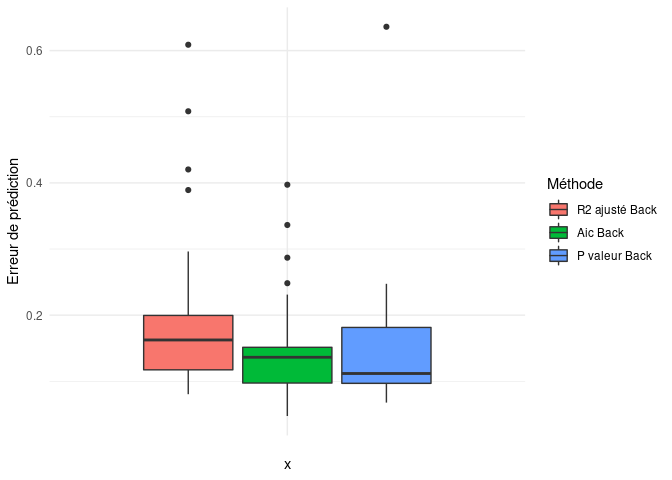

```r
error.stepwise.backward<-as.data.frame(stepwise.backward.TDM$error)
colnames(error.stepwise.backward) <- c("R2 ajusté Back","Aic Back","P valeur Back")

error.stepwise.backward<- error.stepwise.backward %>% mutate("ID"=seq.int(nrow(error.stepwise.backward)))
error.stepwise.backward <- error.stepwise.backward %>% melt(id.var="ID")
colnames(error.stepwise.backward) <- c("ID","Méthode","Erreur")

ggplot(error.stepwise.backward) +
  aes(x = "", y = Erreur, fill = Méthode) +
  geom_boxplot(shape = "circle") +
  labs(y = "Erreur de prédiction") +
  theme_minimal()
```

```r
best.stepwise.backward <- error.stepwise.backward%>% filter(Méthode=="Aic Back")
```

## régression penalisée Lasso et Ridge

Les méthodes de séléction vues jusqu’à présent permettent de choisir un meilleur modèle. Toutefois ces méthodes sont très variables. Pour réduire cette variabilité on peut s’orienter vers les modèles de régression pénalisés qui consistent à ajouter un terme de pénalité au modèle. On s’intéresse à deux variantes:

- Régression Lasso: consiste à ajouter une pénalité sous la forme $\lambda \sum_{j=1}^p|\beta_j|$, avec $\beta_j$ les coefficients ,$\lambda$ paramètre de pénalisation et $p$ le nombre de prédicteurs. Cette variante permet de sélection certaines en varibles en forçant certains coefficients à passer à $0$.

```r
var="TDM"
reps=30
alpha=1
err_lasso<- rep(0,reps)
data <- data_p
pertinence_lasso<-pertinence_vars_dataframe(data,var,0)

for(k in 1:reps){

  #Decoupage apprentissage/test
  tr <- sample(1:n,floor(n*(2/3)))
  data_train<-data %>% slice(tr)
  data_test<-data %>% slice(-tr)

  Xtrain <- model.matrix(TDM~., data_train)[,-1]
  Ytrain <- data_train$TDM
  Xtest <- model.matrix(TDM~., data_test)[,-1]
  Ytest  <- data_test$TDM

  lasso <-  cv.glmnet(Xtrain, Ytrain, alpha = alpha,type.measure="mse")
  lambda.min <- lasso$lambda.min
  model_lasso <- glmnet(Xtrain, Ytrain, alpha = alpha, lambda = lambda.min)
  pred_lasso <- model_lasso %>% predict(Xtest) %>% as.vector()


  liste_var_lasso <-rownames(coef(model_lasso, s = lambda.min))[coef(model_lasso, s        =lambda.min)[,1]!= 0 ][2:ncol(data)]

  liste_var_lasso <- liste_vars(liste_var_lasso)

  for(var_pertinente in liste_var_lasso){
    if(is.na(var_pertinente)!=TRUE){
      pertinence_lasso["lasso",var_pertinente]<-pertinence_lasso["lasso",var_pertinente]+1
    }
  }

  #Erreur de prédiction
    err_lasso[k] <-RMSE(as.numeric(unlist(Ytest)),pred_lasso)

}
```

```r
pertinence_lasso
```

```
##        T HR PR CL PD MA SI FM SH
## lasso 30 13 25 26 30 30 23 25 28
```

- Régression Ridge: consiste à ajouter une pénalité sous la forme $\lambda \sum_{j=1}^p\beta_j²$, avec $\beta_j$ les coefficients ,$\lambda$ paramètre de pénalisation et $p$ le nombre de prédicteurs. Cette variante est moins biaisée que la première mais ne permet pas une sélection de variable.

```r
var="TDM"
reps=30
alpha=0
err_ridge<- rep(0,reps)


for(k in 1:reps){

  #Decoupage apprentissage/test
  tr <- sample(1:n,floor(n*(2/3)))
  data_train<-data %>% slice(tr)
  data_test<-data %>% slice(-tr)

  Xtrain <- model.matrix(TDM~., data_train)[,-1]
  Ytrain <- data_train$TDM
  Xtest <- model.matrix(TDM~., data_test)[,-1]
  Ytest  <- data_test$TDM

  ridge <-  cv.glmnet(Xtrain, Ytrain, alpha = alpha,type.measure="mse")
  lambda.min <- ridge$lambda.min
  model_ridge <- glmnet(Xtrain, Ytrain, alpha = alpha, lambda = lambda.min)

  pred_ridge <- model_ridge %>% predict(Xtest) %>% as.vector()



  # Erreur de orédiction
  err_ridge[k] <-RMSE(as.numeric(unlist(Ytest)),pred_ridge)

}
```

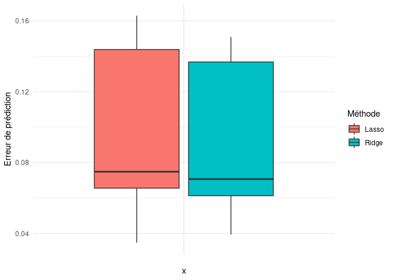

```r
error_ridge_lasso<-as.data.frame(cbind(err_lasso,err_ridge))
colnames(error_ridge_lasso) <- c("Lasso","Ridge")

error_ridge_lasso<- error_ridge_lasso %>% mutate("ID"=seq.int(nrow(error_ridge_lasso)))
error_ridge_lasso <- error_ridge_lasso %>% melt(id.var="ID")
colnames(error_ridge_lasso) <- c("ID","Méthode","Erreur")

ggplot(error_ridge_lasso) +
  aes(x = "", y = Erreur, fill = Méthode) +
  geom_boxplot(shape = "circle") +
  labs(y = "Erreur de prédiction") +
  theme_minimal()
```

## PCR, PLS et sPLS

Jusqu’à présent nous nous sommes limités à la combinaison linéaire des variables explicatives. Toutefois, nous avons un nombre élevé de prédicateurs donc il est plus intéressant de passer par une réduction de dimension au préalable avant de construire nos modèles. Nous allons nous tourner vers les régressions sur composantes principales qui répondent très bien à cette problematique.

Les régressions sur composantes consistent à trouver de nouvelles composantes $C_1, \ C_2, \, \dots C_q$ avec $q \leq p$ qui s’écrivent le plus souvent comme des combinaisons linéaires des $p$ variables explicatives dans l’idée de diminuer le nombre de paramètres du modèle ou la dépendance entre les covariables. Il existe plusieurs façons de construire ces composantes, dans cette partie nous proposons :

- La régression sous composantes principales **(PCR)** : Il s’agit de faire simplement une ACP sur la matrice des variables explicatives ;

```r
reps=30
err_pcr<- rep(0,reps)


for(k in 1:reps){

  #Decoupage apprentissage/test
  tr <- sample(1:n,floor(n*(2/3)))
  data_train<-data %>% slice(tr)
  data_test<-data %>% slice(-tr)

  Xtrain <- model.matrix(TDM~., data_train)[,-1]
  Ytrain <- data_train$TDM
  Xtest <- model.matrix(TDM~., data_test)[,-1]
  Ytest  <- data_test$TDM
  K<-30
  model_pcr=pcr(TDM~., data=data_train, scale=FALSE, validation="CV", segments=K,trace=FALSE)
  k.pcr=which.min(model_pcr$validation$PRESS)
  pred_pcr=predict(model_pcr,Xtest,ncomp=k.pcr)
  # sqrt(mean squared prediction error)
  err_pcr[k] <- RMSE(Ytest,pred_pcr)


}
```

- La régression “Partial Least Square” **(PLS)**: La principale différence et qu’on ne cherche pas les composantes qui maximisent la variabilités des observations projetées, mais les composantes qui maximisent la colinéarité avec la cible.

```r
reps=30
err_pls<- rep(0,reps)


for(k in 1:reps){

  #Decoupage apprentissage/test
  tr <- sample(1:n,floor(n*(2/3)))
  data_train<-data %>% slice(tr)
  data_test<-data %>% slice(-tr)



  Xtrain <- model.matrix(TDM~., data_train)[,-1]
  Ytrain <- data_train$TDM
  Xtest <- model.matrix(TDM~., data_test)[,-1]
  Ytest  <- data_test$TDM
  K<-30
  model_pls<-plsr(TDM~., data=data_train, scale=FALSE, validation="CV", segments=K,trace=FALSE)


  k.pls=which.min(model_pls$validation$PRESS)

  pred_pls=predict(model_pls,Xtest,ncomp=k.pls)

  #Erreur de prédiction

  err_pls[k] <- RMSE(Ytest,pred_pls)
}
```

- La régression “Sparse Partial Least Squares” **(sPLS)**: consiste à faire une régression **PLS** tout en ajoutant une pénalité type **Lasso**.

[output not shown]

[output cut: 275 more lines]

[output not shown]

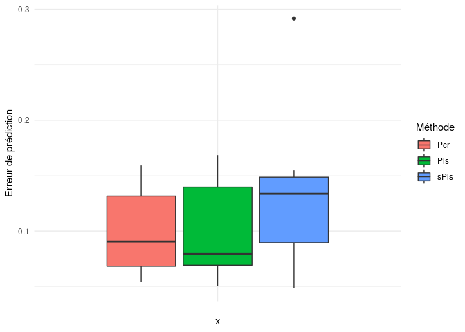

```r
error_pcr_pls_spls<- as.data.frame(cbind(err_pcr,err_pls,err_spls))
colnames(error_pcr_pls_spls) <- c("Pcr","Pls","sPls")
error_pcr_pls_spls <- error_pcr_pls_spls%>% mutate("ID"=seq.int(nrow(error_pcr_pls_spls)))
error_pcr_pls_spls <- error_pcr_pls_spls %>% melt(id.var="ID")
colnames(error_pcr_pls_spls) <- c("ID","Méthode","Erreur")

ggplot(error_pcr_pls_spls) +
  aes(x = "", y = Erreur, fill = Méthode) +
  geom_boxplot(shape = "circle") +
  labs(y = "Erreur de prédiction") +
  theme_minimal()
```

# Comparaison des résulatas

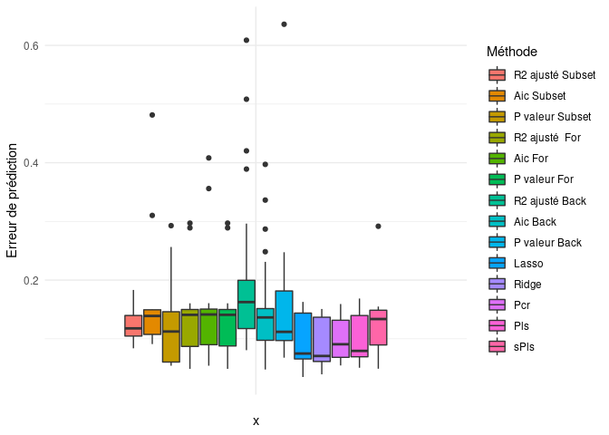

```r
error_all<-rbind(error.subset,error.stepwise.forward,error.stepwise.backward,error_ridge_lasso,error_pcr_pls_spls)

colnames(error_all) <- c("ID","Méthode","Erreur")

ggplot(error_all) +
  aes(x = "", y = Erreur, fill = Méthode) +
  geom_boxplot(shape = "circle") +
  labs(y = "Erreur de prédiction") +
  theme_minimal()
```

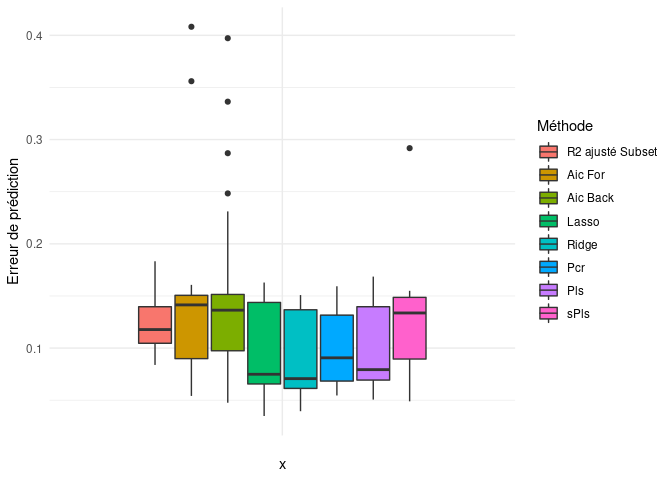

```r
error_all<-rbind(best.subset,best.stepwise.forward,best.stepwise.backward,error_ridge_lasso,error_pcr_pls_spls)

colnames(error_all) <- c("ID","Méthode","Erreur")

ggplot(error_all) +
  aes(x = "", y = Erreur, fill = Méthode) +
  geom_boxplot(shape = "circle") +
  labs(y = "Erreur de prédiction") +
  theme_minimal()
```

# Pertinence variables

```r
reps <- 30
pertinence <- rbind(pertinence.subset,pertinence.stepwise.forward,pertinence.stepwise.backward,pertinence_lasso)
pertinence <- rbind(pertinence,"Total"=round((colSums(pertinence)/(nrow(pertinence)*reps)*100),digits = 2))
rownames(pertinence) <- c("Subset Aic","Subset R2","Subset pvalue","Forward Aic", "Forward R2","Forward Pvalue","Backward Aic", "Backward R2","Backward Pvalue","Lasso","Pourcetage")
paged_table(pertinence)
```

|  | T | HR | PR | CL | PD | MA | SI | FM | SH |
| --- | --- | --- | --- | --- | --- | --- | --- | --- | --- |
| Subset Aic | 10.00 | 8.00 | 8.00 | 9 | 9 | 10.00 | 10.00 | 7.00 | 8.00 |
| Subset R2 | 2.00 | 0.00 | 0.00 | 0 | 0 | 8.00 | 0.00 | 0.00 | 0.00 |
| Subset pvalue | 10.00 | 2.00 | 6.00 | 3 | 10 | 10.00 | 4.00 | 3.00 | 4.00 |
| Forward Aic | 30.00 | 8.00 | 11.00 | 17 | 30 | 30.00 | 24.00 | 23.00 | 16.00 |
| Forward R2 | 30.00 | 1.00 | 5.00 | 8 | 30 | 30.00 | 18.00 | 13.00 | 8.00 |
| Forward Pvalue | 30.00 | 1.00 | 5.00 | 8 | 30 | 30.00 | 19.00 | 14.00 | 8.00 |
| Backward Aic | 30.00 | 28.00 | 25.00 | 29 | 30 | 30.00 | 29.00 | 27.00 | 29.00 |
| Backward R2 | 30.00 | 12.00 | 16.00 | 15 | 27 | 30.00 | 17.00 | 16.00 | 15.00 |
| Backward Pvalue | 7.00 | 9.00 | 6.00 | 8 | 5 | 18.00 | 2.00 | 5.00 | 5.00 |
| Lasso | 30.00 | 13.00 | 25.00 | 26 | 30 | 30.00 | 23.00 | 25.00 | 28.00 |

[output cut: 1 more lines]